# **Practice Project: Insurance Cost Analysis**

**Goal:** Predict individual medical insurance charges using demographic and lifestyle data.

## 📘 Overview

This project explores how factors like age, BMI, and smoking status affect medical costs.  
A Polynomial Ridge Regression model was trained and evaluated to estimate insurance charges.

## 💡 Insights

- Smoking status is the dominant cost driver.
- Age has moderate impact; BMI contributes less strongly.
- Ensemble or segmented models could further improve predictions for extreme charges.

In this project, I performed analytics operations on an insurance database that uses the below mentioned parameters.

| Parameter | Description | Content type |
| --- | --- | --- |
| age | Age in years | integer |
| gender | Male or Female | integer (1 or 2) |
| bmi | Body mass index | float |
| no_of_children | Number of children | integer |
| smoker | Whether smoker or not | integer (0 or 1) |
| region | Which US region - NW, NE, SW, SE | integer (1,2,3 or 4 respectively) |
| charges | Annual Insurance charges in USD | float |

## 🎯 Project Objectives

This project focuses on understanding and predicting medical insurance costs using regression techniques.  
Beyond modeling, it emphasizes feature relationships, interpretability, and performance evaluation.

### In this project, I:

- **Loaded and prepared** the dataset using `pandas`, ensuring all missing and inconsistent values were handled systematically.
- **Performed exploratory data analysis (EDA)** to uncover key cost drivers such as age, BMI, and smoking status.
- **Visualized relationships** between numeric and categorical features using correlation heatmaps, boxplots, and regression plots.
- **Built and compared regression models**, starting with:
  - **Simple Linear Regression** for single-variable relationships.
  - **Multiple Linear Regression** using all available features.
- **Refined model performance** through **Ridge Regression** and **Polynomial Features** to capture non-linear effects and reduce overfitting.
- **Evaluated models** using metrics such as R², MAE, and RMSE to assess accuracy and reliability.
- **Derived actionable insights**, identifying smoking and age as the strongest predictors of higher insurance charges.

# Setup

Libraries Used:

- `pandas` for managing the data.
- [`numpy`](https://numpy.org/?utm_medium=Exinfluencer&utm_source=Exinfluencer&utm_content=000026UJ&utm_term=10006555&utm_id=NA-SkillsNetwork-Channel-SkillsNetworkCoursesIBMML0187ENSkillsNetwork31430127-2021-01-01) for mathematical operations.
- `sklearn` for machine learning and machine-learning-pipeline related functions.
- `seaborn` for visualizing the data.
- [`matplotlib`](https://matplotlib.org/?utm_medium=Exinfluencer&utm_source=Exinfluencer&utm_content=000026UJ&utm_term=10006555&utm_id=NA-SkillsNetwork-Channel-SkillsNetworkCoursesIBMML0187ENSkillsNetwork31430127-2021-01-01) for additional plotting tools.

```python
%pip install seaborn
```

### Importing Required Libraries

```python
import pandas as pd
import matplotlib.pyplot as plt
import numpy as np
import seaborn as sns
from sklearn.pipeline import Pipeline
from sklearn.preprocessing import StandardScaler, PolynomialFeatures
from sklearn.linear_model import LinearRegression, Ridge
from sklearn.metrics import mean_squared_error, r2_score
from sklearn.model_selection import cross_val_score, train_test_split
from pathlib import Path
```

### Download the dataset

Run the cell below to load the dataset.

```python
# Locate the CSV relative to the notebook location
# Works whether you're in /notebooks or the project root
base_dir = Path.cwd()
if (base_dir / "data").exists():
    path = base_dir / "data" / "medical_insurance_dataset.csv"
elif (base_dir.parent / "data").exists():
    path = base_dir.parent / "data" / "medical_insurance_dataset.csv"
else:
    raise FileNotFoundError("Could not locate 'medical_insurance_dataset.csv'")

df = pd.read_csv(path)
print("✅ Data loaded successfully from:", path)
```

```
✅ Data loaded successfully from: c:\Users\Allen\Desktop\Data Analyst Projects\insurance-cost-analysis\data\medical_insurance_dataset.csv
```

# Step 1 : Import the dataset

Import the dataset into a `pandas` dataframe. Note that there are currently no headers in the CSV file.

Print the first 10 rows of the dataframe to confirm successful loading.

```python
df = pd.read_csv(path, header=None)
print(df.head(10))
```

```
    0  1       2  3  4  5            6
0  19  1  27.900  0  1  3  16884.92400
1  18  2  33.770  1  0  4   1725.55230
2  28  2  33.000  3  0  4   4449.46200
3  33  2  22.705  0  0  1  21984.47061
4  32  2  28.880  0  0  1   3866.85520
5  31  1  25.740  0  ?  4   3756.62160
6  46  1  33.440  1  0  4   8240.58960
7  37  1  27.740  3  0  1   7281.50560
8  37  2  29.830  2  0  2   6406.41070
9  60  1  25.840  0  0  1  28923.13692
```

Add the headers to the dataframe, as mentioned in the project scenario.

```python
headers = ["age", "gender", "bmi", "no_of_children", "smoker", "region", "charges"]
df.columns = headers
```

Now, replace the '?' entries with 'NaN' values.

```python
df.replace('?', np.nan, inplace = True)
```

# Step 2 : Data Wrangling

Use `dataframe.info()` to identify the columns that have some 'Null' (or NaN) information.

```python
print(df.info())
```

```
<class 'pandas.core.frame.DataFrame'>
RangeIndex: 2772 entries, 0 to 2771
Data columns (total 7 columns):
 #   Column          Non-Null Count  Dtype
---  ------          --------------  -----
 0   age             2768 non-null   object
 1   gender          2772 non-null   int64
 2   bmi             2772 non-null   float64
 3   no_of_children  2772 non-null   int64
 4   smoker          2765 non-null   object
 5   region          2772 non-null   int64
 6   charges         2772 non-null   float64
dtypes: float64(2), int64(3), object(2)
memory usage: 151.7+ KB
None
```

Note there are certain categories with missing values.

Handle missing data:

- For continuous attributes (e.g., age), I replaced missing values with the mean.
- For categorical attributes (e.g., smoker), replaced missing values with the most frequent value.
- Updated the data types of the respective columns.
- Verified the update using `df.info()`.

```python
# Identify the most frequent 'smoker' value
is_smoker = df['smoker'].value_counts().idxmax()

# Replace NaN values in 'smoker' column safely
df = df.assign(smoker=df['smoker'].fillna(is_smoker))

# Calculate mean age (converted to float first)
mean_age = df['age'].astype(float).mean()

# Replace NaN values in 'age' column safely
df = df.assign(age=df['age'].fillna(mean_age))

# Convert columns to integer type as needed
df[['age', 'smoker']] = df[['age', 'smoker']].astype(int)
```

```python
print(df.info())
```

```
<class 'pandas.core.frame.DataFrame'>
RangeIndex: 2772 entries, 0 to 2771
Data columns (total 7 columns):
 #   Column          Non-Null Count  Dtype
---  ------          --------------  -----
 0   age             2772 non-null   int64
 1   gender          2772 non-null   int64
 2   bmi             2772 non-null   float64
 3   no_of_children  2772 non-null   int64
 4   smoker          2772 non-null   int64
 5   region          2772 non-null   int64
 6   charges         2772 non-null   float64
dtypes: float64(2), int64(5)
memory usage: 151.7 KB
None
```

Note: The non-null counts now match up with the other categories

Also note, that the `charges` column has values which are more than 2 decimal places long. Updated the `charges` column such that all values are rounded to nearest 2 decimal places. Verified conversion by printing the first 5 values of the updated dataframe.

```python
df[["charges"]] = np.round(df[["charges"]],2)
print(df.head())
```

```
   age  gender     bmi  no_of_children  smoker  region   charges
0   19       1  27.900               0       1       3  16884.92
1   18       2  33.770               1       0       4   1725.55
2   28       2  33.000               3       0       4   4449.46
3   33       2  22.705               0       0       1  21984.47
4   32       2  28.880               0       0       1   3866.86
```

# Step 3 : Exploratory Data Analysis (EDA)

Implemented the regression plot for `charges` with respect to `bmi`.

```
(0.0, 66902.85800000001)
```

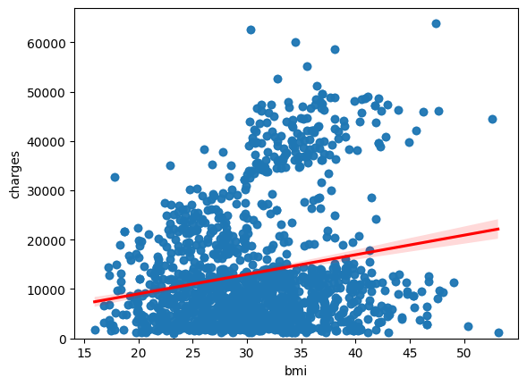

```python
sns.regplot(x="bmi", y="charges", data=df, line_kws={"color": "red"})
plt.ylim(0,)
```

There’s a weak to moderate positive relationship between BMI and medical charges — higher BMI is somewhat associated with higher charges, but BMI alone is not a strong predictor.

To explore other categories, I Implemented the box plot for `charges` with respect to `smoker`.

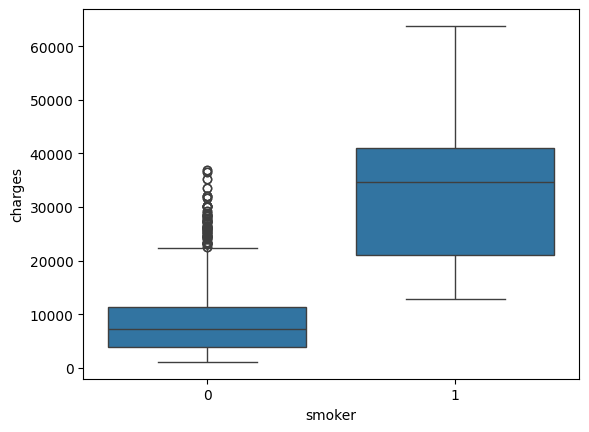

```python
sns.boxplot(x="smoker", y="charges", data=df)
```

## Interpretation

Non-smokers show a median charge of around 7,000$ - 10,000$ with a tight interquartile range; where as smokers' median charges range from 35,000$ - 40,000$. Smokers show fewer datapoints near 0-10k, meaning very few smokers have low medical costs. Maximum charges for smokers exceed 60k, showing extreme cost outliers.

Smoking shows a much stronger and clearer relationship. Leading to potential insight in that, Smoking substantially increases medical insurance costs, likely due to higher incidence of chronic conditions and risk factors associated with tobacco use.

## Assess correlations

Print the correlation matrix for the dataset.

```python
df.corr()
```

|  | age | gender | bmi | no_of_children | smoker | region | charges |
| --- | --- | --- | --- | --- | --- | --- | --- |
| age | 1.000000 | -0.026046 | 0.113048 | 0.037574 | -0.023286 | -0.007167 | 0.298624 |
| gender | -0.026046 | 1.000000 | 0.042924 | 0.016020 | 0.082326 | 0.022213 | 0.062837 |
| bmi | 0.113048 | 0.042924 | 1.000000 | -0.001492 | 0.011489 | 0.271119 | 0.199846 |
| no_of_children | 0.037574 | 0.016020 | -0.001492 | 1.000000 | 0.006362 | -0.025717 | 0.066442 |
| smoker | -0.023286 | 0.082326 | 0.011489 | 0.006362 | 1.000000 | 0.054077 | 0.788783 |
| region | -0.007167 | 0.022213 | 0.271119 | -0.025717 | 0.054077 | 1.000000 | 0.054058 |
| charges | 0.298624 | 0.062837 | 0.199846 | 0.066442 | 0.788783 | 0.054058 | 1.000000 |

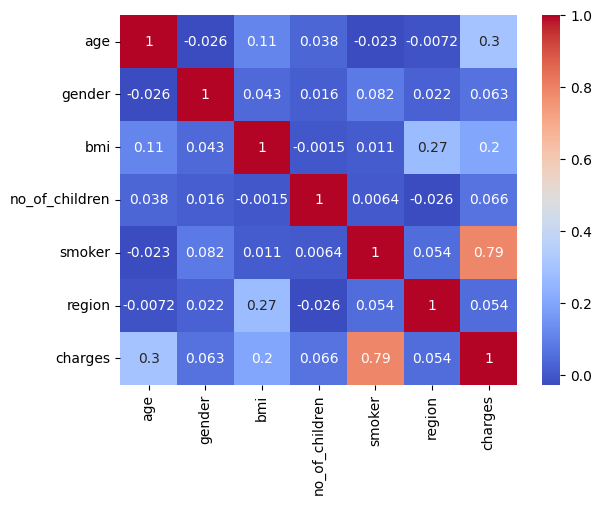

```python
sns.heatmap(df.corr(), annot=True, cmap="coolwarm")
```

Used a heatmap to visualize correlations and explore other correlations if needed. Smoking is by far the most correlated variable with charges, supporting its dominant role in cost prediction --highlighted in the heatmap by the color light red.

## Interpretation

Smoking status shows the strongest correlation with the medical charges by far; having a 0.7887 very strong positive correlation. This confirms the pattens seen in the box plot. The correlation is so strong, it suggests smoking alone explain a large portion of charge variance, and would likely emerge as the most significant predictor in any regression model.

Age shows a moderate positive correlation of 0.2986 having a significant effect on increased medical charges, but the effect is far weaker than smoking.

BMI shows a 0.1998 weak positive correlation -- consistent with what was seen in the earlier regession plot. While BMI plays a role, it is not a dominant one.

# Step 4 : Model Development

Fitted a linear regression model that may be used to predict the `charges` value, just by using the `smoker` attribute of the dataset. Printed the $ R^2 $ score of this model.

```python
X= df[['smoker']]
Y = df['charges']
lm = LinearRegression()
lm.fit(X,Y)
print(lm.score(X, Y))
```

```
0.6221791733924185
```

Fitted a linear regression model that may be used to predict the `charges` value, just by using all other attributes of the dataset. Print the $ R^2 $ score of this model. Note an improvement in the performance.

```python
Z = df[["age", "gender", "bmi", "no_of_children", "smoker", "region"]]
lm.fit(Z,Y)
print(lm.score(Z, Y))
```

```
0.7504083820289634
```

Created a training pipeline that uses `StandardScaler()`, `PolynomialFeatures()` and `LinearRegression()` to create a model that can predict the `charges` value using all the other attributes of the dataset. There should be even further improvement in the performance.

```python
Input=[('scale',StandardScaler()), ('polynomial', PolynomialFeatures(include_bias=False)), ('model', LinearRegression())]
pipe=Pipeline(Input)
Z = Z.astype(float)
pipe.fit(Z,Y)
ypipe=pipe.predict(Z)
print(r2_score(Y,ypipe))
```

```
0.8452576213500093
```

A good R^2 value is produced, now we must test how well the model generalizes on unseen data or we risk overfitting.

# Step 5 : Model Refinement

“This step uses polynomial features and ridge regularization to capture non-linear relationships while controlling overfitting.”

Splitted the data into training and testing subsets, assuming that 20% of the data will be reserved for testing. We are testing how well the model generalizes on unseen data. This prevents overfitting -- when a model memorizes data instead of learning patterns.

```python
x_train, x_test, y_train, y_test = train_test_split(Z, Y, test_size=0.2, random_state=1)
```

Initialized a Ridge regressor that used hyperparameter $ \alpha = 0.1 $. Fit the model using training data data subset. Print the $ R^2 $ score for the testing data.

This reduces overfitting by shrinking large coefficients that might over react to the noise in the data.

```python
RidgeModel=Ridge(alpha=0.1)
RidgeModel.fit(x_train, y_train)
yhat = RidgeModel.predict(x_test)
print(r2_score(y_test,yhat))
```

```
0.6760807731582404
```

To further dial in we applied polynomial transformation to the training parameters with degree=2. Used this transformed feature set to fit the same regression model, as above, using the training subset. Printed the $ R^2 $ score for the testing subset.

```python
pr = PolynomialFeatures(degree=2)
x_train_pr = pr.fit_transform(x_train)
x_test_pr = pr.fit_transform(x_test)
RidgeModel.fit(x_train_pr, y_train)
y_hat = RidgeModel.predict(x_test_pr)
print(r2_score(y_test,y_hat))
```

```
0.7835631107608146
```

# Interpretation

Because insurance costs are not purely linear (e.g. the impact of BMI might increase exponentially beyond certain thresholds). Polynomial terms allow the model to capture nonlinear relatioinships that simple linear models cannot.

The R^2 score increased from .676 to 0.784, meaning the model now explains 78.4% of the variance.

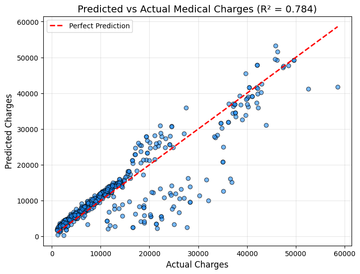

```python
import matplotlib.pyplot as plt
import numpy as np
from sklearn.metrics import r2_score

# Generate predictions using your final (polynomial ridge) model
y_hat = RidgeModel.predict(x_test_pr)

# Calculate R² again for the title
r2 = r2_score(y_test, y_hat)

# Create scatter plot
plt.figure(figsize=(8,6))
plt.scatter(y_test, y_hat, color='dodgerblue', alpha=0.6, edgecolor='k')
plt.plot([y_test.min(), y_test.max()], [y_test.min(), y_test.max()], 'r--', lw=2, label='Perfect Prediction')

# Labels and title
plt.xlabel("Actual Charges", fontsize=12)
plt.ylabel("Predicted Charges", fontsize=12)
plt.title(f"Predicted vs Actual Medical Charges (R² = {r2:.3f})", fontsize=14)
plt.legend()
plt.grid(True, alpha=0.3)
plt.show()
```

# Interpretation

### Model Fit and Residual Patterns

The model captures the overall trend between actual and predicted medical charges (R² = 0.78),  
but it exhibits systematic bias:

Together, the predicted vs. actual and residual plots confirm that the model performs well overall but struggles with extreme cost values.

# Additional Visualizations and Insights

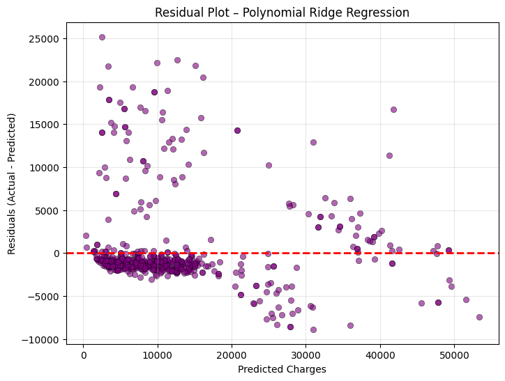

```python
import matplotlib.pyplot as plt
import seaborn as sns

# Compute residuals
residuals = y_test - y_hat  # or (y_test - model.predict(x_test_pr))

plt.figure(figsize=(8,6))
sns.scatterplot(x=y_hat, y=residuals, alpha=0.6, color='purple', edgecolor='k')
plt.axhline(0, color='red', linestyle='--', lw=2)
plt.xlabel("Predicted Charges")
plt.ylabel("Residuals (Actual - Predicted)")
plt.title("Residual Plot – Polynomial Ridge Regression")
plt.grid(alpha=0.3)
plt.show()
```

The model generalizes well for mid-range insurance charges but struggles with extreme cases. These systematic residual patterns suggest:

High-cost patients may have unique combinations of risk factors (e.g., smoker × BMI × age) not fully captured by the model.

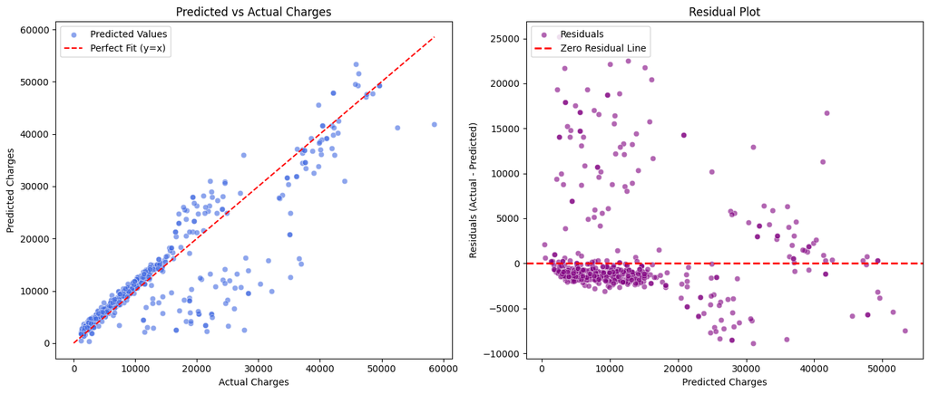

```python
fig, ax = plt.subplots(1, 2, figsize=(14, 6))

# --- Left: Predicted vs Actual ---
sns.scatterplot(x=y_test, y=y_hat, color='royalblue', alpha=0.6, ax=ax[0], label="Predicted Values")
ax[0].plot([0, y_test.max()], [0, y_test.max()], 'r--', label="Perfect Fit (y=x)")
ax[0].set_title('Predicted vs Actual Charges')
ax[0].set_xlabel("Actual Charges")
ax[0].set_ylabel("Predicted Charges")
ax[0].legend(loc='upper left')

# --- Right: Residual Plot ---
sns.scatterplot(x=y_hat, y=y_test - y_hat, color='purple', alpha=0.6, ax=ax[1], label="Residuals")
ax[1].axhline(0, color='red', linestyle='--', lw=2, label="Zero Residual Line")
ax[1].set_title('Residual Plot')
ax[1].set_xlabel("Predicted Charges")
ax[1].set_ylabel("Residuals (Actual - Predicted)")
ax[1].legend(loc='upper left')

plt.tight_layout()
plt.show()
```

Strong overall fit: The model achieves a good balance between bias and variance, explaining roughly 78% of the variance (R² ≈ 0.78).

Systematic variance pattern: Prediction errors increase with higher medical charges, suggesting nonlinear or interaction effects not fully captured even after polynomial expansion.

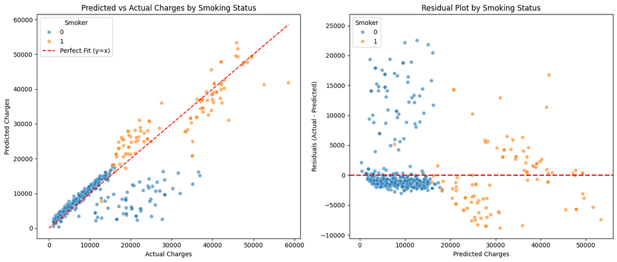

```python
fig, ax = plt.subplots(1, 2, figsize=(14, 6))

# --- Left: Predicted vs Actual, color by smoker ---
sns.scatterplot(x=y_test, y=y_hat, hue=df.loc[y_test.index, "smoker"], alpha=0.6, ax=ax[0])
ax[0].plot([0, y_test.max()], [0, y_test.max()], 'r--', label="Perfect Fit (y=x)")
ax[0].set_title('Predicted vs Actual Charges by Smoking Status')
ax[0].set_xlabel("Actual Charges")
ax[0].set_ylabel("Predicted Charges")
ax[0].legend(title="Smoker", loc='upper left')

# --- Right: Residual Plot ---
sns.scatterplot(x=y_hat, y=y_test - y_hat, hue=df.loc[y_test.index, "smoker"], alpha=0.6, ax=ax[1])
ax[1].axhline(0, color='red', linestyle='--', lw=2)
ax[1].set_title('Residual Plot by Smoking Status')
ax[1].set_xlabel("Predicted Charges")
ax[1].set_ylabel("Residuals (Actual - Predicted)")
ax[1].legend(title="Smoker", loc='upper left')

plt.tight_layout()
plt.show()
```

### Interpretation:

The model distinguishes smokers and non-smokers effectively, as shown by the clear cost separation. However, residuals reveal that predictions for smokers show higher variance and slight overprediction bias. This suggests potential benefits from modeling interaction effects or log-transforming charges to stabilize variance.

## Model Evaluation and Insights

In other words, the model captures general cost trends but struggles with extreme cases on both ends.

```python
from sklearn.metrics import r2_score, mean_absolute_error, mean_squared_error
import numpy as np
import pandas as pd

# Predict with each model correctly
y_pred_lr = lm.predict(x_test)                         # Linear Regression
y_pred_ridge = RidgeModel.predict(x_test_pr)           # Ridge trained on polynomial features
y_pred_poly = RidgeModel.predict(x_test_pr)            # If same model used for polynomial ridge
# (If you had separate ridge models, adjust variable names accordingly)

# Calculate metrics
metrics = {
    'Model': ['Linear Regression', 'Polynomial Ridge Regression'],
    'R²': [
        r2_score(y_test, y_pred_lr),
        r2_score(y_test, y_pred_ridge)
    ],
    'MAE': [
        mean_absolute_error(y_test, y_pred_lr),
        mean_absolute_error(y_test, y_pred_ridge)
    ],
    'RMSE': [
        np.sqrt(mean_squared_error(y_test, y_pred_lr)),
        np.sqrt(mean_squared_error(y_test, y_pred_ridge))
    ]
}

results_df = pd.DataFrame(metrics).round(3)
results_df
```

|  | Model | R² | MAE | RMSE |
| --- | --- | --- | --- | --- |
| 0 | Linear Regression | 0.680 | 4407.355 | 6495.939 |
| 1 | Polynomial Ridge Regression | 0.784 | 3077.367 | 5340.732 |

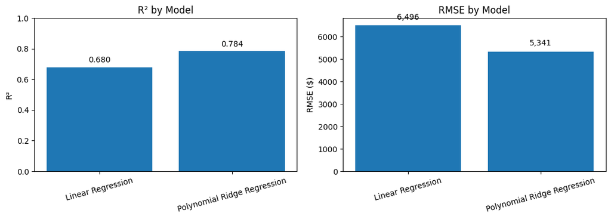

```python
models = results_df["Model"].tolist()
r2 = results_df["R²"].tolist()
rmse = results_df["RMSE"].tolist()

fig, ax = plt.subplots(1, 2, figsize=(11, 4))

# --- Left: R² (higher is better)
ax[0].bar(models, r2)
ax[0].set_ylim(0, 1)
ax[0].set_title("R² by Model")
ax[0].set_ylabel("R²")
for i, v in enumerate(r2):
    ax[0].text(i, v + 0.02, f"{v:.3f}", ha="center", va="bottom")

# --- Right: RMSE (lower is better)
ax[1].bar(models, rmse)
ax[1].set_title("RMSE by Model")
ax[1].set_ylabel("RMSE ($)")
for i, v in enumerate(rmse):
    ax[1].text(i, v + (max(rmse)*0.03), f"{v:,.0f}", ha="center", va="bottom")

for a in ax:
    a.tick_params(axis='x', labelrotation=15)

plt.tight_layout()
plt.savefig("../visuals/model_comparison.png", dpi=300, bbox_inches="tight")
plt.show()
```

### Model Comparison Summary

We evaluated both regression models on their ability to predict insurance charges.

# Model Applicability in Real-World Scenarios

The polynomial ridge regression model performs well for the majority of patients, capturing around 78% of variance in medical charges. It reliably predicts typical costs based on age, BMI, and smoking status, making it useful for portfolio-level trend analysis and pricing decisions.

However, for high-cost patients (outliers), the model tends to **underpredict** their true charges and exhibits higher variance.  
In real-world insurance modeling, these cases would typically be handled separately—either through specialized high-cost claim models or ensemble techniques that combine linear and nonlinear approaches.  
The current model would therefore be deployed for the **general population**, while **high-risk, high-cost segments** would require more complex, event-driven predictive modeling.